# Lab 4a

Functional Programming

Utrecht Summer School: Statistical Programming with R

```r
library(dplyr)
knitr::opts_chunk$set(eval=params$answers)
```

# 1 Function returning the cumulative sum of a vector

In this exercise you’ll write your own cumulative sum function. This function returns the cumulative sums of the elements of a vector, and will work identically to the base R function `cumsum()`, e.g.

```r
cumsum(x = 1:4)
```

```
## [1]  1  3  6 10
```

We’ll take the following steps:

1. Write the loop 2, Make container object
2. Collect the results in a container object
3. Embed 1 to 3 in the function `my_cumsum(x)`

But first make the vector `x` with the values `1:4`.

```r
x <- 1:4
```

1. Now write a loop that computes the cumulative sums of `x`. This requires the following steps:
   1. Define a `counter`, e.g. `i`
   2. Define a `sequence` of integers that runs from 1 to the length of the vector `1:4`
   3. The consecutive iterations should return the sum of `x[1:i]`
   4. Use the `print()` command to print the outcome at each iteration

```r
for (i in 1:4) {

  print(sum(x[1:i]))

}
```

```
## [1] 1
## [1] 3
## [1] 6
## [1] 10
```

2. Now make a container object. The most obvious would be to make it a numeric vector with length is `length(x)`. Check the help page of the function `numeric()` on how to do that.

```r
out <- numeric(length = length(x))
```

3. Now rewrite the loop so that it stores the cumulative sums in the container vector. Run the loop and check the content of the container vector.

```r
for (i in 1:4) {

  out[i] <- sum(x[1:i])

}

out
```

```
## [1]  1  3  6 10
```

4. Now include the container object and the loop in your function `my_cumsum(x)`, where `x` is the function argument denoting the vector for which the cumulative sums have to be returned. Run the function, and check whether it appears in your workspace.

```r
my_cumsum <- function(x) {

  out <- numeric(length(x))

  for (i in 1:length(x)) {

     out[i] <- sum(x[1:i])
  }

  return(out)
}
```

2. Apply your function to the vector `-4:4`, and compare its result to that of the base R function.

```r
cbind("my function" = my_cumsum(-4:4), "base R" = cumsum(-4:4))
```

```
##       my function base R
##  [1,]          -4     -4
##  [2,]          -7     -7
##  [3,]          -9     -9
##  [4,]         -10    -10
##  [5,]         -10    -10
##  [6,]          -9     -9
##  [7,]          -7     -7
##  [8,]          -4     -4
##  [9,]           0      0
```

# 2 Display the scatter plots with `cyl` as dependent variable

In the lecture slides there is an example of a loop that returns scatter plots with `mpg` as dependent variable and all other variables in `mtcars` as predictor. In this exercise you write a loop that plots `cyl` on the y-axis and all other variable in `mtcars` on the x-axes.

1. Make an object `dv_pos` that takes the value of the position of `cyl` in `mtcars`.

```r
dv_pos <- 2
```

2. Make the object `sequence` for `i` that takes the values 1 to 11, but that skips the value of `dv_pos`.

```r
sequence <-(1:11)[-dv_pos]
```

3. Now copy-paste the code on the lecture slide “Adding the variable names”. Change the sequence `2:11` in the object `sequence` you made in the previous exercise, and change the reference `1` in the square brackets to `dv_pos`. Then run the loop to check if it works as intended.

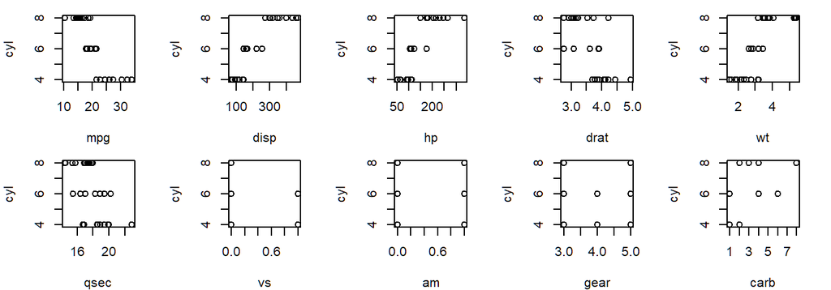

```r
vars <- colnames(mtcars)
par(mfrow = c(2, 5), mar = c(4, 4, 1, 2))
for (i in sequence) {
  plot(x = mtcars[, i], y = mtcars[, dv_pos], xlab = vars[i], ylab = vars[dv_pos])
}
```

# 3 Advanced

We will now write the function `plot_mtcars` with the argument `dv_pos` (without default) that makes the scatter plots for a dependent variable of the user’s choice. Then we make it more general so that it can be applied to any data set.

1. Define the function with the expressions for `sequence`, `vars`, and the loop for making the plots. Run the function and check if it appears in your workspace.

```r
plot_mtcars <- function(dv_pos) {

  sequence <-(1:11)[-dv_pos]
  vars     <- colnames(mtcars)

  for (i in sequence) {
    plot(x = mtcars[, i], y = mtcars[, dv_pos], xlab = vars[i], ylab = vars[dv_pos])

  }
}
```

2. Now run the function with `dv_pos = 3` to check if it works. Place the `par(...)` statement before the function call to tell R how to position the plots.

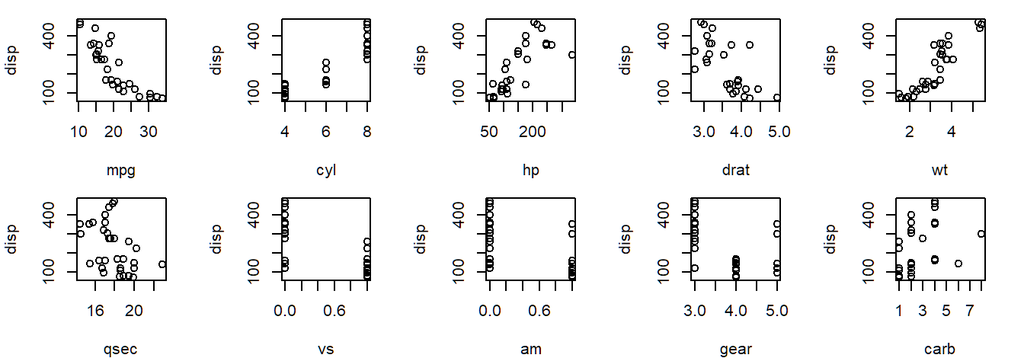

```r
par(mfrow = c(2, 5), mar = c(4, 4, 1, 2))
plot_mtcars(3)
```

3. To make this function applicable to any data set, change the name of the function `plot_mtcars` into `plot_dv`, add the argument `dataset` to it, and change the references to `mtcars` within the function to `dataset`.

```r
plot_dv <- function(dv_pos, dataset) {

  sequence <-(1:ncol(dataset))[-dv_pos]
  vars     <- colnames(dataset)

  for (i in sequence) {
    plot(x = dataset[, i], y = dataset[, dv_pos], xlab = vars[i], ylab = vars[dv_pos])

  }
}
```

2. Now load the package `MASS` into workspace, and try the function on the data set `UScrime` with the variable `y` (crime rate) on the y-axis. Adapt the `par(...)` statement to the number of variable in `UScrime`, and adapt `fig.asp`.

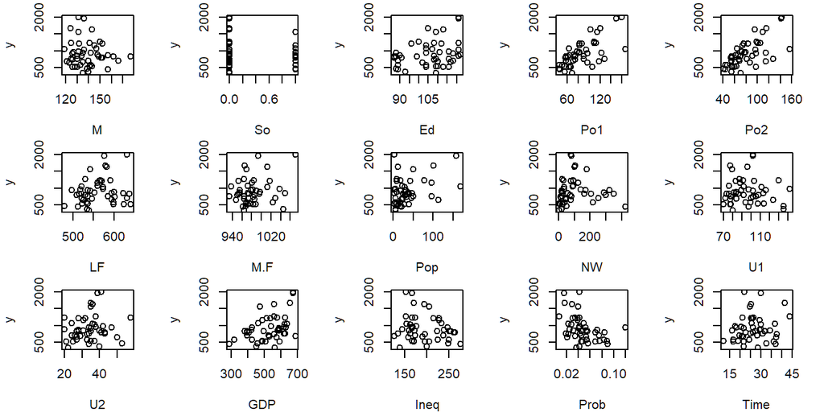

```r
library(MASS)
par(mfrow = c(3, 5), mar = c(4, 4, 1, 2))
plot_dv(16, MASS::UScrime)
```

End of practical